# 15 Summarise categorical data

**Outcomes**

- Summarise categorical variables by creating appropriate frequency tables and contingency tables.
- Use bar plots appropriately to visualise categorical variables.

In the same way that there is a need to summarise numerical data, to be able to make conclusions, we need to summarise categorical variables. Below is a snippet from a table in Kampmann_2023. It shows the gestational age categories and numbers (and percentages) of patients from the vaccinated group, belonging to each.

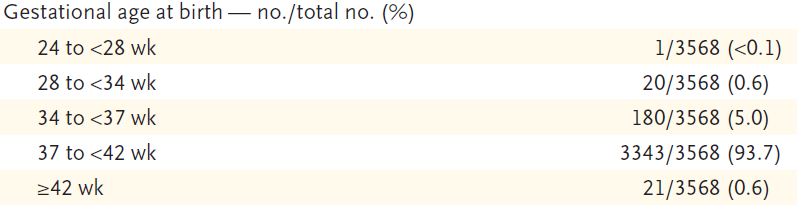

This frequency table is simple to understand. Calculate the total number of patients included in the categories. What did you discover? What may be reasons for that?

If we wanted to know how the gestational age categories compared between males and females, a sample of the “raw” data we would need would look like the table below. (This is fictional data, not the actual data from Kampmann_2023.)

| gestational_age | sex |
| --- | --- |
| 37_to_<42_wk | female |
| 37_to_<42_wk | female |
| 37_to_<42_wk | female |
| 37_to_<42_wk | male |
| 37_to_<42_wk | female |
| 37_to_<42_wk | female |
| 37_to_<42_wk | female |
| 37_to_<42_wk | male |
| 37_to_<42_wk | male |
| 37_to_<42_wk | female |

To answer our question we need to summarise the two variables in a contingency table (or two-way table) like the one below.

| gestational_age | female | male |
| --- | --- | --- |
| 24_to_<28_wk | 2 | NA |
| 28_to_<34_wk | 13 | 4 |
| 34_to_<37_wk | 97 | 95 |
| 37_to_<42_wk | 1689 | 1651 |
| >42_wk | 7 | 10 |

This table is also fairly simple, but can become quite confusing when you start having to answer questions about it. Answer the following questions about the table above.

- What is the total number of females?
- What is the total number of patients in the >42 weeks category?
- What percentage of males are in the 28 to <34 weeks category?
- What percentage of those in the 34 to <37 weeks category, are female?

**Expand to see the answers**

You would have discovered that you need the *column totals* and the *row totals* to answer the questions.

| gestational_age | female | male | total |
| --- | --- | --- | --- |
| 24_to_<28_wk | 2 | NA | NA |
| 28_to_<34_wk | 13 | 4 | 17 |
| 34_to_<37_wk | 97 | 95 | 192 |
| 37_to_<42_wk | 1689 | 1651 | 3340 |
| >42_wk | 7 | 10 | 17 |
| total | 1808 | NA | NA |

The last two questions can be confusing, because you must carefully select the correct total to calculate the percentage.

The data can also be visualised with a bar plot. Below we demonstrate two different plots from the same data. What is the difference? Why would you choose one over the other?

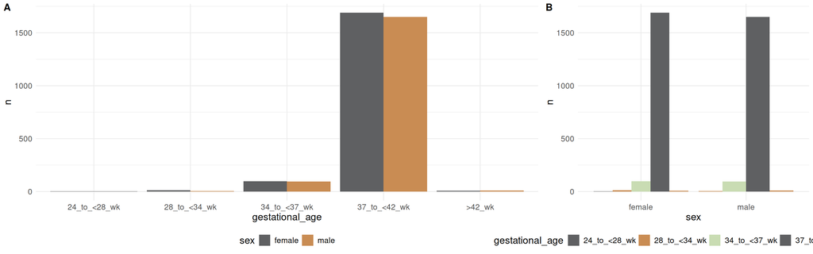